# MODULE 7 PROJECT ANN

## Bank Churn Prediction - Problem Statement

### Description

#### Background & Context

Businesses like banks that provide service have to worry about the problem of 'Churn' i.e. customers leaving and joining another service provider. It is important to understand which aspects of the service influence a customer's decision in this regard. Management can concentrate efforts on the improvement of service, keeping in mind these priorities.

#### Objective

- Given a Bank customer, build a neural network-based classifier that can determine whether they will leave or not in the next 6 months.

#### Data Description

The case study is from an open-source dataset from Kaggle. The dataset contains 10,000 sample points with 14 distinct features such as CustomerId, CreditScore, Geography, Gender, Age, Tenure, Balance, etc.

#### Data Dictionary:

- CustomerId: Unique ID which is assigned to each customer
- Surname: Last name of the customer
- CreditScore: It defines the credit history of the customer.
- Geography: A customer’s location
- Gender: It defines the Gender of the customer
- Age: Age of the customer
- Tenure: Number of years for which the customer has been with the bank
- NumOfProducts: It refers to the number of products that a customer has purchased through the bank.
- Balance: Account balance
- HasCrCard: It is a categorical variable that decides whether the customer has a credit card or not.
- EstimatedSalary: Estimated salary
- isActiveMember: It is a categorical variable that decides whether the customer is an active member of the bank or not (Active member in the sense, using bank products regularly, making transactions, etc )
- Exited: It is a categorical variable that decides whether the customer left the bank within six months or not. It can take two values

  ```
                0=No ( Customer did not leave the bank )

                1=Yes ( Customer left the bank )
  ```

### Let's import the relevant libraries

```python
# To help with reading and manipulation of data
import pandas as pd
import numpy as np

# To help with data visualisation
import seaborn as sns
import matplotlib.pyplot as plt

# for data processing and splitting
from sklearn import preprocessing
from sklearn.model_selection import train_test_split


# to scale the data using z-score
from scipy.stats import zscore

# for neural network model building and tuning
import tensorflow as tf
from tensorflow.keras.models import Sequential
from tensorflow.keras.layers import Dense, Dropout
from tensorflow.keras import optimizers
import keras
from keras import backend as K
from tensorflow.keras.optimizers import Adam
from keras.layers import BatchNormalization
from tensorflow.keras import regularizers
from tensorflow.keras import backend
from keras import callbacks
import random
random.seed(1)
np.random.seed(1)
tf.random.set_seed(1)
from tensorflow.keras.wrappers.scikit_learn import KerasClassifier
from sklearn.model_selection import RandomizedSearchCV

#To oversample and undersample the data
from imblearn.over_sampling import SMOTE
from imblearn.under_sampling import RandomUnderSampler


#To get different model performance metrics
from sklearn.metrics import accuracy_score, confusion_matrix, precision_score, recall_score, f1_score, roc_auc_score, roc_curve


#To suppress warnings
import warnings
warnings.filterwarnings("ignore")

#to make the codes well structured automatically
%load_ext nb_black
```

```python
# to read the data
data = pd.read_csv("Churn.csv")
data.head()  # to display the first 5 rows of the data
```

|  | RowNumber | CustomerId | Surname | CreditScore | Geography | Gender | Age | Tenure | Balance | NumOfProducts | HasCrCard | IsActiveMember | EstimatedSalary | Exited |
| --- | --- | --- | --- | --- | --- | --- | --- | --- | --- | --- | --- | --- | --- | --- |
| 0 | 1 | 15634602 | Hargrave | 619 | France | Female | 42 | 2 | 0.00 | 1 | 1 | 1 | 101348.88 | 1 |
| 1 | 2 | 15647311 | Hill | 608 | Spain | Female | 41 | 1 | 83807.86 | 1 | 0 | 1 | 112542.58 | 0 |
| 2 | 3 | 15619304 | Onio | 502 | France | Female | 42 | 8 | 159660.80 | 3 | 1 | 0 | 113931.57 | 1 |
| 3 | 4 | 15701354 | Boni | 699 | France | Female | 39 | 1 | 0.00 | 2 | 0 | 0 | 93826.63 | 0 |
| 4 | 5 | 15737888 | Mitchell | 850 | Spain | Female | 43 | 2 | 125510.82 | 1 | 1 | 1 | 79084.10 | 0 |

- The dataset looks consistent with the description provided in the Data Dictionary. However, the RowNumber,CustomerId,and Surname columns do not contain any information relevant to the project objectives. These columns will be dropped shortly in the project.

```python
data.shape  # To check the number of rows and columns in the data set
```

```
(10000, 14)
```

- The dataset has 10000 rows and 14 columns

```python
df = data.copy()  # To save a copy of the original data
```

```python
df.duplicated().sum()  # To check for duplicated rows in the data set
```

```
0
```

- There is no duplicated row in the dataset

```python
df.info()  # To print the concise summary of the dataset
```

```
<class 'pandas.core.frame.DataFrame'>
RangeIndex: 10000 entries, 0 to 9999
Data columns (total 14 columns):
 #   Column           Non-Null Count  Dtype
---  ------           --------------  -----
 0   RowNumber        10000 non-null  int64
 1   CustomerId       10000 non-null  int64
 2   Surname          10000 non-null  object
 3   CreditScore      10000 non-null  int64
 4   Geography        10000 non-null  object
 5   Gender           10000 non-null  object
 6   Age              10000 non-null  int64
 7   Tenure           10000 non-null  int64
 8   Balance          10000 non-null  float64
 9   NumOfProducts    10000 non-null  int64
 10  HasCrCard        10000 non-null  int64
 11  IsActiveMember   10000 non-null  int64
 12  EstimatedSalary  10000 non-null  float64
 13  Exited           10000 non-null  int64
dtypes: float64(2), int64(9), object(3)
memory usage: 1.1+ MB
```

- It can be further seen that there are a total of 14 columns and 10000 number of rows in the dataset.
- All columns' data types are a mix of integer, float and object type.
- The number of non-null value in all columns is equal to number of total rows in the dataset.This means that no feature contain missing observations. We can further confirm this using `isna()` method.
- It is also worthy of mention here that the Exited is our target feature based on the problem statement above while other features are the independent variables(predictors)

```python
df.isnull().sum()  # To further confirm if there are missing values in the dataset or not
```

```
RowNumber          0
CustomerId         0
Surname            0
CreditScore        0
Geography          0
Gender             0
Age                0
Tenure             0
Balance            0
NumOfProducts      0
HasCrCard          0
IsActiveMember     0
EstimatedSalary    0
Exited             0
dtype: int64
```

- There is no missing value in the dataset

```python
df.columns  # To check the names of the features on the dataset
```

```
Index(['RowNumber', 'CustomerId', 'Surname', 'CreditScore', 'Geography',
       'Gender', 'Age', 'Tenure', 'Balance', 'NumOfProducts', 'HasCrCard',
       'IsActiveMember', 'EstimatedSalary', 'Exited'],
      dtype='object')
```

- Just as said earlier, from the project objectives, it can be observed that our target feature is 'Exited' while others are independent features

```python
# let's drop RowNumber and CustomerId and Surname columns
df.drop(["RowNumber", "CustomerId", "Surname"], axis=1, inplace=True)
```

```python
df.describe().T  # To display the statistical summary of the features
```

|  | count | mean | std | min | 25% | 50% | 75% | max |
| --- | --- | --- | --- | --- | --- | --- | --- | --- |
| CreditScore | 10000.0 | 650.528800 | 96.653299 | 350.00 | 584.00 | 652.000 | 718.0000 | 850.00 |
| Age | 10000.0 | 38.921800 | 10.487806 | 18.00 | 32.00 | 37.000 | 44.0000 | 92.00 |
| Tenure | 10000.0 | 5.012800 | 2.892174 | 0.00 | 3.00 | 5.000 | 7.0000 | 10.00 |
| Balance | 10000.0 | 76485.889288 | 62397.405202 | 0.00 | 0.00 | 97198.540 | 127644.2400 | 250898.09 |
| NumOfProducts | 10000.0 | 1.530200 | 0.581654 | 1.00 | 1.00 | 1.000 | 2.0000 | 4.00 |
| HasCrCard | 10000.0 | 0.705500 | 0.455840 | 0.00 | 0.00 | 1.000 | 1.0000 | 1.00 |
| IsActiveMember | 10000.0 | 0.515100 | 0.499797 | 0.00 | 0.00 | 1.000 | 1.0000 | 1.00 |
| EstimatedSalary | 10000.0 | 100090.239881 | 57510.492818 | 11.58 | 51002.11 | 100193.915 | 149388.2475 | 199992.48 |
| Exited | 10000.0 | 0.203700 | 0.402769 | 0.00 | 0.00 | 0.000 | 0.0000 | 1.00 |

### Let's look at the unique values of the categorical features

```python
# To display the unique values in each categorical feature
col_cats = df.select_dtypes(["object"])
for i in col_cats.columns:
    print("Unique values in", i, "are:")
    print(col_cats[i].value_counts())
    print("*" * 50)
```

```
Unique values in Geography are:
France     5014
Germany    2509
Spain      2477
Name: Geography, dtype: int64
Unique values in Gender are:
Male      5457
Female    4543
Name: Gender, dtype: int64
```

- While Geography feature has 3 unique values, Gender has two. All the bank's clients are majorly from France, Germany, and Spain

## Univariate Analysis

```python
# function to plot a boxplot and a histogram along the same scale.


def histogram_boxplot(data, feature, figsize=(12, 7), kde=False, bins=None):
    """
    Boxplot and histogram combined

    data: dataframe
    feature: dataframe column
    figsize: size of figure (default (12,7))
    kde: whether to the show density curve (default False)
    bins: number of bins for histogram (default None)
    """
    f2, (ax_box2, ax_hist2) = plt.subplots(
        nrows=2,  # Number of rows of the subplot grid= 2
        sharex=True,  # x-axis will be shared among all subplots
        gridspec_kw={"height_ratios": (0.25, 0.75)},
        figsize=figsize,
    )  # creating the 2 subplots
    sns.boxplot(
        data=data, x=feature, ax=ax_box2, showmeans=True, color="violet"
    )  # boxplot will be created and a star will indicate the mean value of the column
    sns.histplot(
        data=data, x=feature, kde=kde, ax=ax_hist2, bins=bins, palette="winter"
    ) if bins else sns.histplot(
        data=data, x=feature, kde=kde, ax=ax_hist2
    )  # For histogram
    ax_hist2.axvline(
        data[feature].mean(), color="green", linestyle="--"
    )  # Add mean to the histogram
    ax_hist2.axvline(
        data[feature].median(), color="black", linestyle="-"
    )  # Add median to the histogram
```

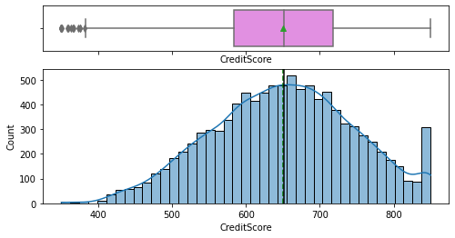

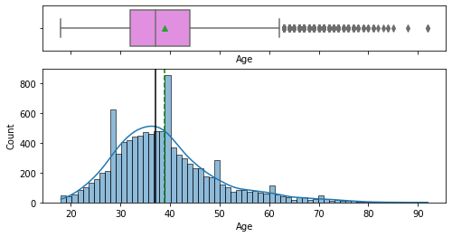

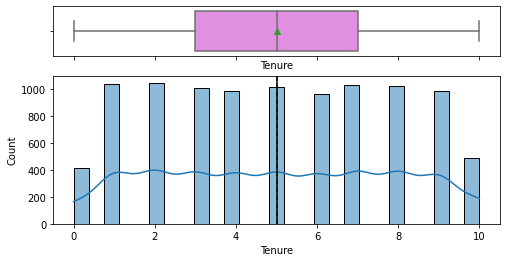

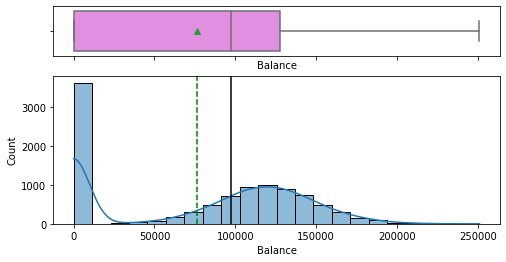

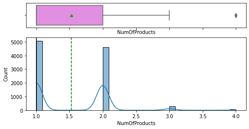

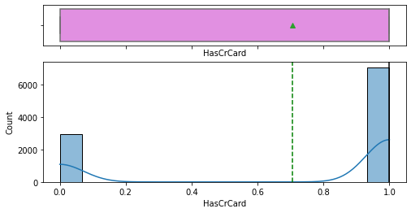

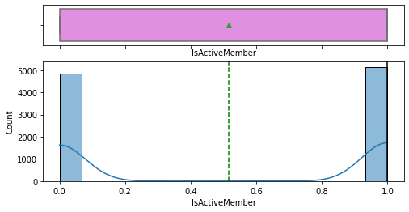

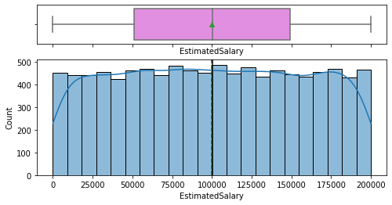

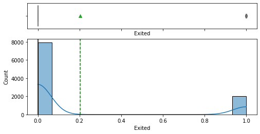

```python
col = [
    "CreditScore",
    "Age",
    "Tenure",
    "Balance",
    "NumOfProducts",
    "HasCrCard",
    "IsActiveMember",
    "EstimatedSalary",
    "Exited",
]  # Selecting the numerical features
for item in col:
    histogram_boxplot(
        df, item, kde=True, figsize=(8, 4)
    )  # To plot the histogram and boxplots of the each numerical feature
```

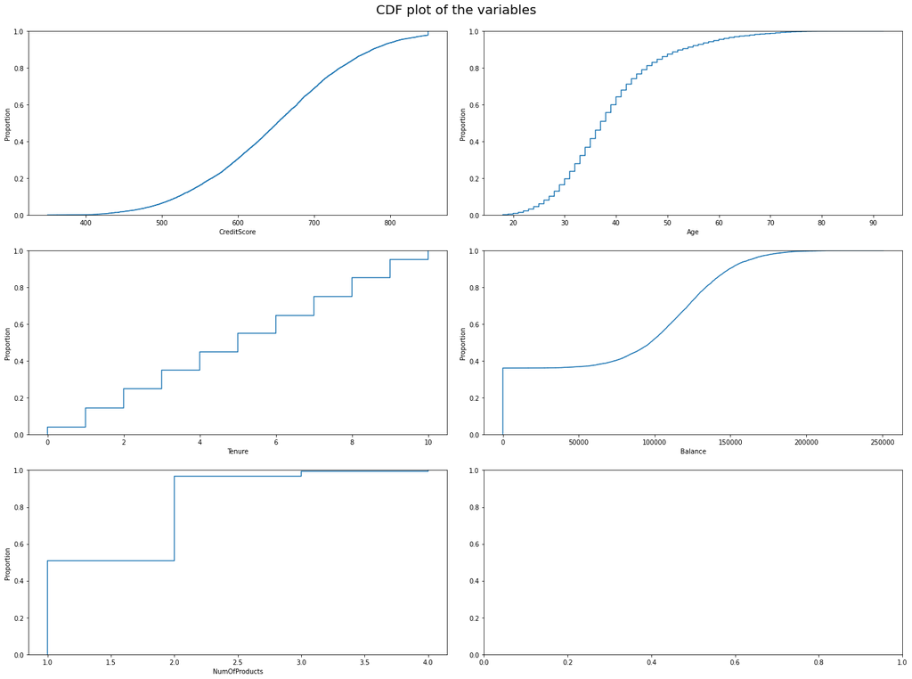

```python
# to plot the cummulative distribution function of the variables
fig, axes = plt.subplots(3, 2, figsize=(20, 15))
fig.suptitle("CDF plot of the variables", fontsize=20)
counter = 0
for ii in range(3):
    sns.ecdfplot(ax=axes[ii][0], x=df[col[counter]])
    counter = counter + 1
    if counter != 5:
        sns.ecdfplot(ax=axes[ii][1], x=df[col[counter]])
        counter = counter + 1
    else:
        pass

fig.tight_layout(pad=2.0)
```

```python
# function to create labeled barplots


def labeled_barplot(data, feature, perc=False, n=None):
    """
    Barplot with percentage at the top

    data: dataframe
    feature: dataframe column
    perc: whether to display percentages instead of count (default is False)
    n: displays the top n category levels (default is None, i.e., display all levels)
    """

    total = len(data[feature])  # length of the column
    count = data[feature].nunique()
    if n is None:
        plt.figure(figsize=(count + 1, 5))
    else:
        plt.figure(figsize=(n + 1, 5))

    plt.xticks(rotation=90, fontsize=15)
    ax = sns.countplot(
        data=data,
        x=feature,
        palette="Paired",
        order=data[feature].value_counts().index[:n].sort_values(),
    )

    for p in ax.patches:
        if perc == True:
            label = "{:.1f}%".format(
                100 * p.get_height() / total
            )  # percentage of each class of the category
        else:
            label = p.get_height()  # count of each level of the category

        x = p.get_x() + p.get_width() / 2  # width of the plot
        y = p.get_height()  # height of the plot

        ax.annotate(
            label,
            (x, y),
            ha="center",
            va="center",
            size=12,
            xytext=(0, 5),
            textcoords="offset points",
        )  # annotate the percentage

    plt.show()  # show the plot
```

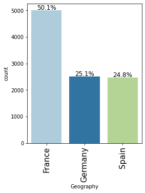

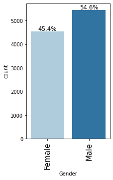

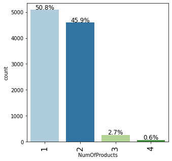

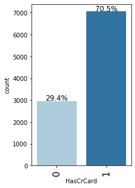

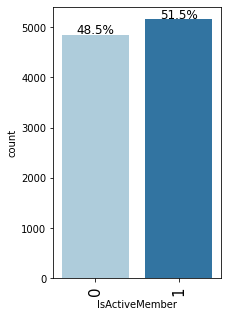

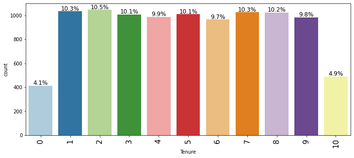

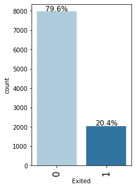

```python
# Creating labeled bar plots on some variables
perc_col = (
    "Geography",
    "Gender",
    "NumOfProducts",
    "HasCrCard",
    "IsActiveMember",
    "Tenure",
    "Exited",
)
for item in perc_col:
    labeled_barplot(df, item, perc=True)
```

- 50.1% of the bank customers are located in France while customers located in Germany and Spain are approximately same in proportion.
- 54.6% of the banks customers are Males while the rest are females.
- Approximately half of the bank's customers have only purchased one products while those who purchased 4 products are the least in proportion.
- Over 70% of the customers have credit card. This shows that credit card is the flagship loan product the bank has.
- 51.5% of the customers are active customers while the rest are not. This suggests that some customers even have the bank's credit cards and are not transacting with it.
- 90% of the customers have stayed between 1-9 years with the bank.
- 79.6% of the bank's customers are still with the bank while only 20.4% has exited the bank.

```
0    7963
1    2037
Name: Exited, dtype: int64
```

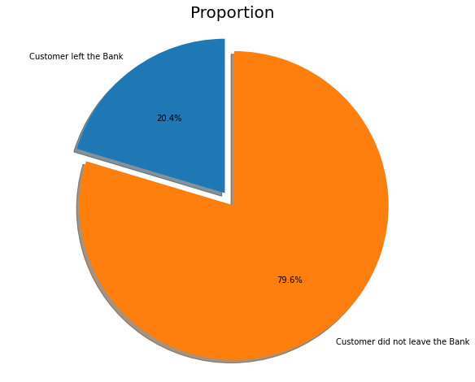

```python
print(df.Exited.value_counts())
labels = "Customer left the Bank", "Customer did not leave the Bank"

sizes = [df.Exited[df["Exited"] == 1].count(), df.Exited[df["Exited"] == 0].count()]
explode = (0, 0.1)
fig1, ax1 = plt.subplots(figsize=(10, 8))
ax1.pie(
    sizes, explode=explode, labels=labels, autopct="%1.1f%%", shadow=True, startangle=90
)
ax1.axis("equal")
plt.title("Proportion", size=20)
plt.show()
```

- This pie chart shows that the actual distribution of classes is itself imbalanced for the target variable('Exited').
- Only ~20% of the customers in this dataset have actually exited the bank.

## Bivariate Analysis

```python
### Function to plot distributions


def distribution_plot_wrt_target(data, predictor, target):

    fig, axs = plt.subplots(2, 2, figsize=(12, 10))

    target_uniq = data[target].unique()

    axs[0, 0].set_title("Distribution of target for target=" + str(target_uniq[0]))
    sns.histplot(
        data=data[data[target] == target_uniq[0]],
        x=predictor,
        kde=True,
        ax=axs[0, 0],
        color="teal",
    )

    axs[0, 1].set_title("Distribution of target for target=" + str(target_uniq[1]))
    sns.histplot(
        data=data[data[target] == target_uniq[1]],
        x=predictor,
        kde=True,
        ax=axs[0, 1],
        color="orange",
    )

    axs[1, 0].set_title("Boxplot w.r.t target")
    sns.boxplot(data=data, x=target, y=predictor, ax=axs[1, 0], palette="gist_rainbow")

    axs[1, 1].set_title("Boxplot (without outliers) w.r.t target")
    sns.boxplot(
        data=data,
        x=target,
        y=predictor,
        ax=axs[1, 1],
        showfliers=False,
        palette="gist_rainbow",
    )

    plt.tight_layout()
    plt.show()
```

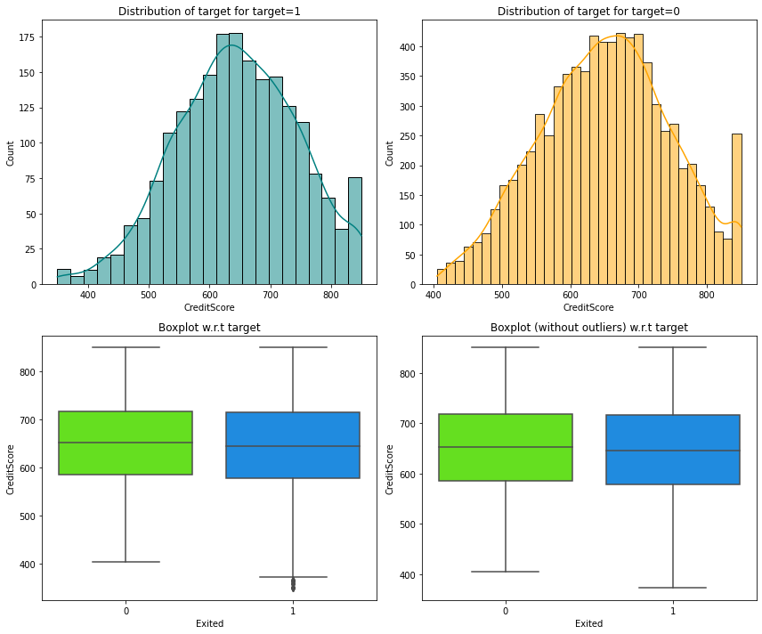

```python
distribution_plot_wrt_target(
    df, "CreditScore", "Exited"
)  # To plot CreditScore against Exited
```

- There is no real significant difference in the distribution of customers the exited the bank and those that did not exit based on their credit score.

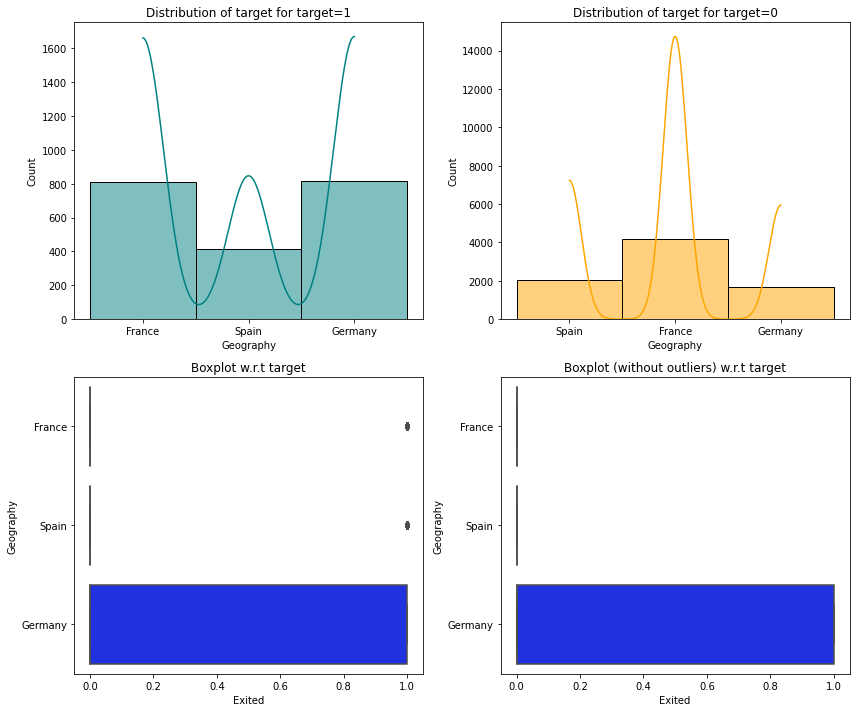

```python
distribution_plot_wrt_target(
    df, "Geography", "Exited"
)  # To plot Geography against Exited
```

- The boxplot shows that most exited customers are located in Germany.

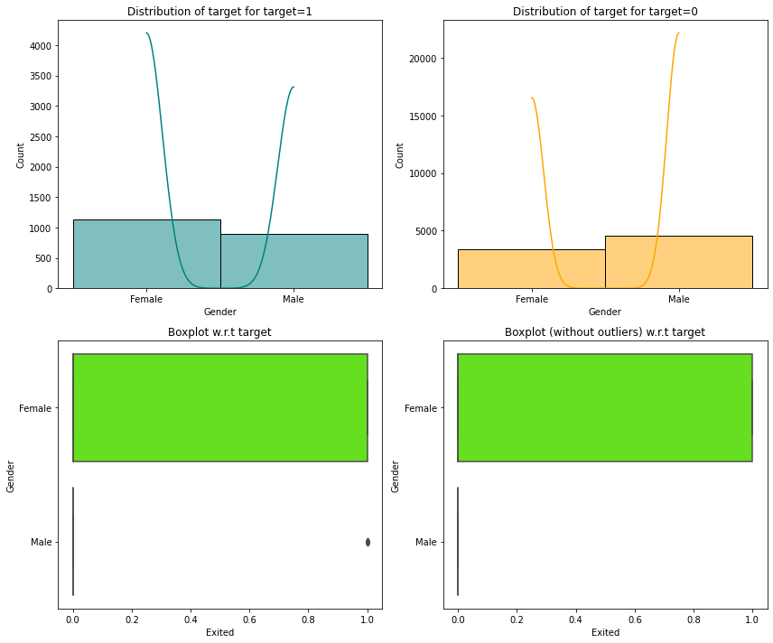

```python
distribution_plot_wrt_target(df, "Gender", "Exited")  # To plot Gender against Exited
```

- It is obvious from the plot above that the customers leaving the bank are mostly females. The bank might need to design female-friendly products that will appeal to the females better. Having a dedicated customer service channels for females might also help.

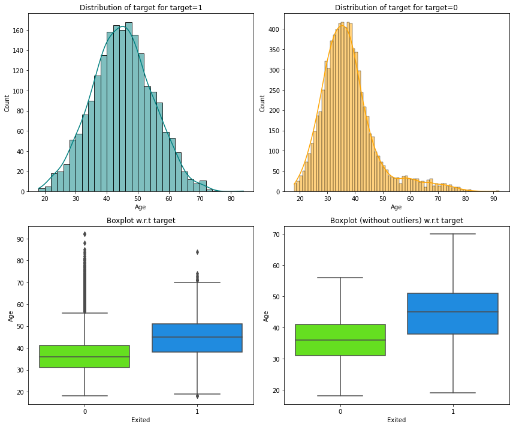

```python
distribution_plot_wrt_target(df, "Age", "Exited")  # To plot Age against Exited
```

- The Age distribution of exited customers is close to normal distribution. The exited customers are mostly between 35-55 years of age as shown in the boxplot.

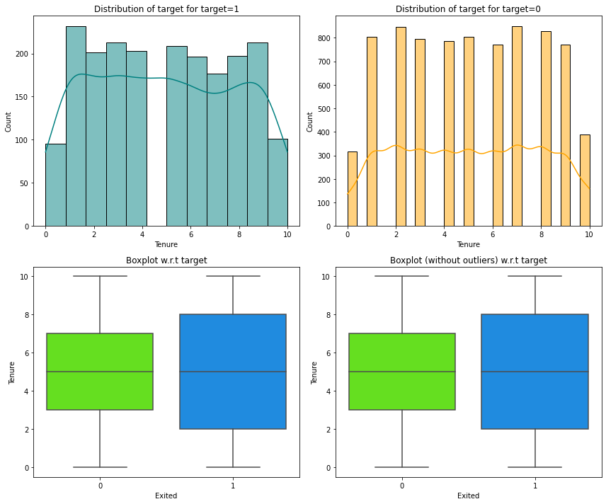

```python
distribution_plot_wrt_target(df, "Tenure", "Exited")  # To plot Tenure against Exited
```

- Most exited customers have spent between 2 to 8 years with bank

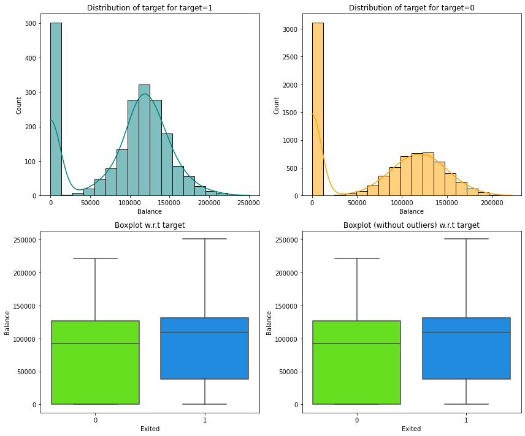

```python
distribution_plot_wrt_target(df, "Balance", "Exited")  # To plot Balance against Exited
```

- The account balance of mostly exited customers is below 150,000.

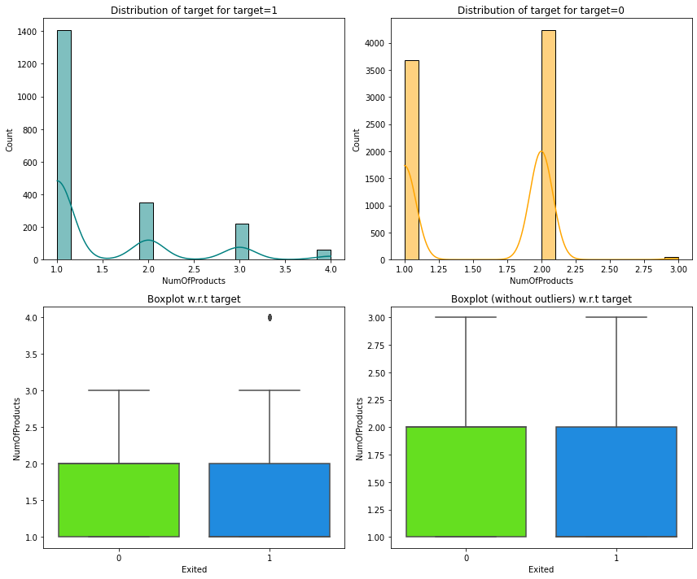

```python
distribution_plot_wrt_target(
    df, "NumOfProducts", "Exited"
)  # To plot NumOfProducts against Exited
```

- The highest number of exited customers only purchased one product of the bank as shown in barplot. The higher the number of products the customers purchased, the lower the number of exited customers.

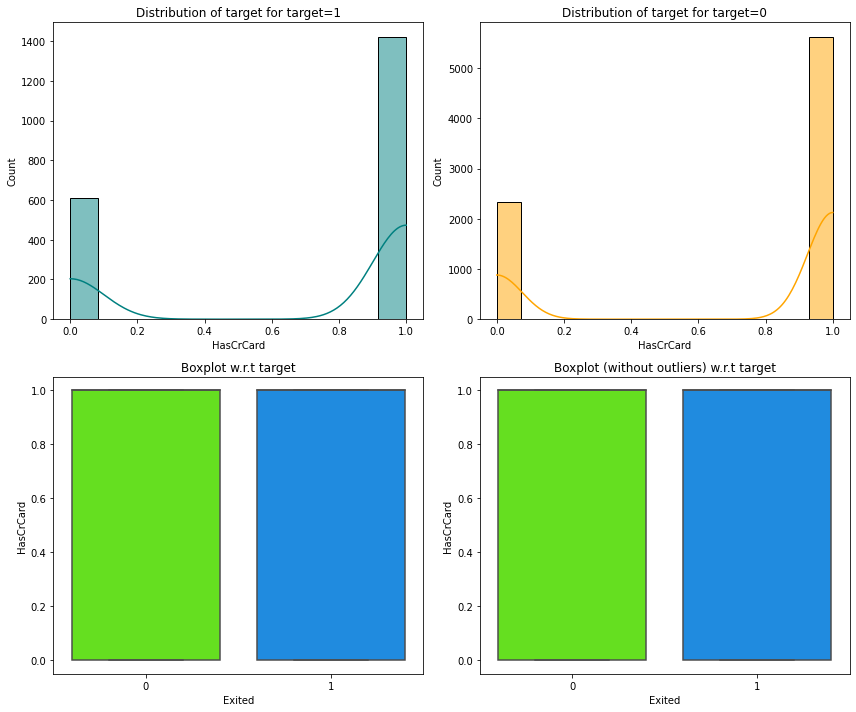

```python
distribution_plot_wrt_target(
    df, "HasCrCard", "Exited"
)  # To plot HasCrCard against Exited
```

- The customers distribution on whether they have credit card or not is the same for both customers that left the bank and those that did not leave.

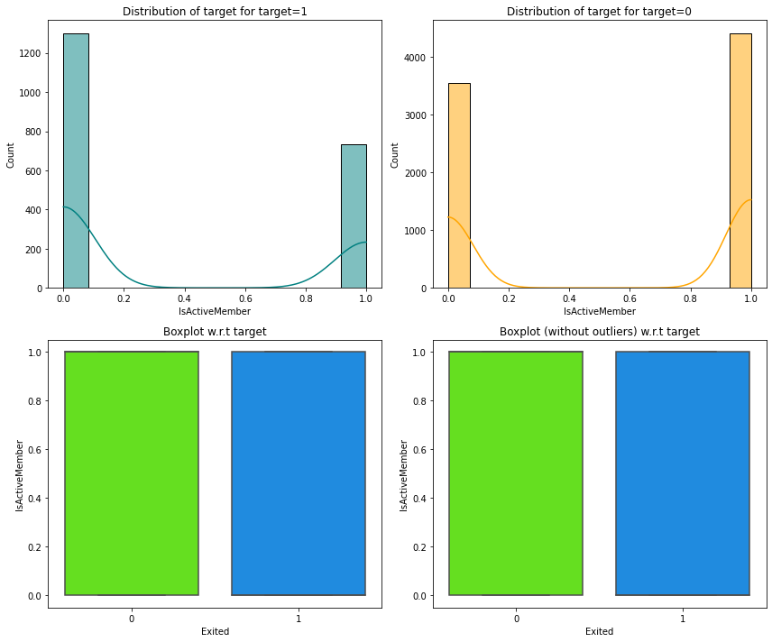

```python
distribution_plot_wrt_target(
    df, "IsActiveMember", "Exited"
)  # To plot IsActiveMember against Exited
```

- Most of the customers that left are not active customers. They have not been using the bank's products regularly as shown in the bar plot.

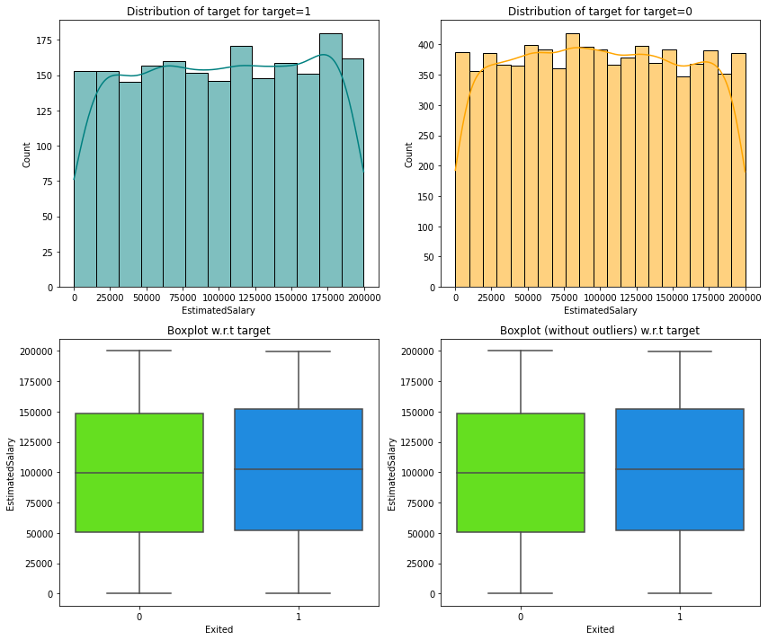

```python
distribution_plot_wrt_target(
    df, "EstimatedSalary", "Exited"
)  # To plot EstimatedSalary against Exited
```

- There is no real significant difference in the Estimated salary distribution of customers the exited the bank and those that did not exit.

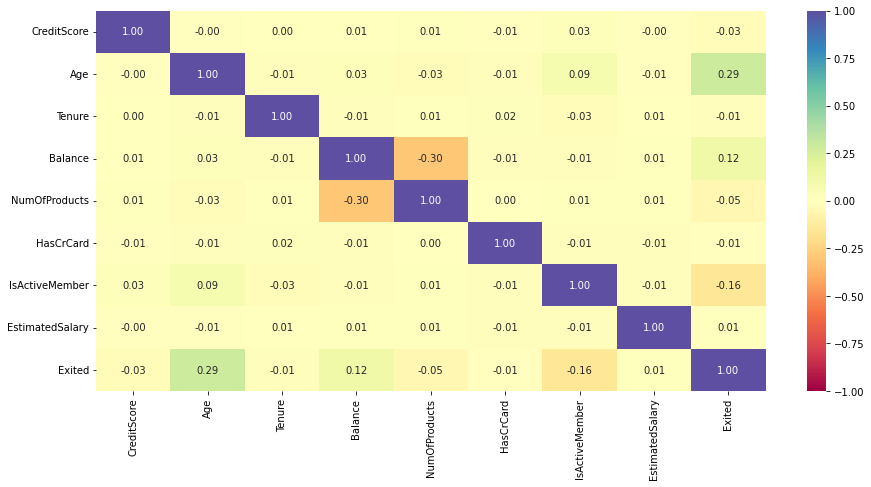

```python
# To plot the heat map of all correlation coefficients between pairs of the variables
plt.figure(figsize=(15, 7))
sns.heatmap(df[col].corr(), annot=True, vmin=-1, vmax=1, fmt=".2f", cmap="Spectral")
plt.show()
```

- It appears there is no strong correlation between pairs of all features in the dataset. With exception of Balance Vs NumOfProducts(-0.30) and Exited Vs Age(0.29), all other relationships among the features are very weak with some even indicating no relationship(zero correlation) at all like CreditScore Vs Age,CreditScore Vs Tenure,and NumberOfProducts Vs HasCrCard.

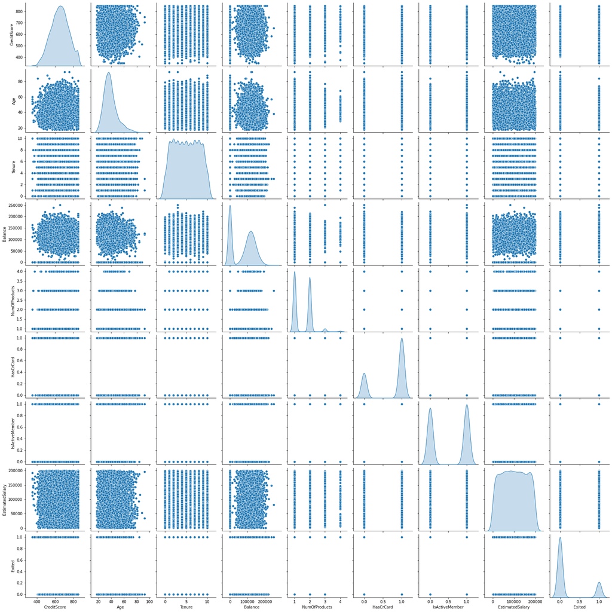

```python
# To plot the pairplot of all pairs of the variables in the dataset
sns.pairplot(data=df[col], diag_kind="kde")
plt.show()
```

- We can see varying distributions among the variables which need further investigations.

## Characteristics of Exited Customers

```python
df[df["Exited"] == 1].describe(
    include="all"
).T  # To show the statistical summary of Exited Customers only along all features
```

|  | count | unique | top | freq | mean | std | min | 25% | 50% | 75% | max |
| --- | --- | --- | --- | --- | --- | --- | --- | --- | --- | --- | --- |
| CreditScore | 2037.0 | NaN | NaN | NaN | 645.351497 | 100.321503 | 350.0 | 578.0 | 646.0 | 716.0 | 850.0 |
| Geography | 2037 | 3 | Germany | 814 | NaN | NaN | NaN | NaN | NaN | NaN | NaN |
| Gender | 2037 | 2 | Female | 1139 | NaN | NaN | NaN | NaN | NaN | NaN | NaN |
| Age | 2037.0 | NaN | NaN | NaN | 44.837997 | 9.761562 | 18.0 | 38.0 | 45.0 | 51.0 | 84.0 |
| Tenure | 2037.0 | NaN | NaN | NaN | 4.932744 | 2.936106 | 0.0 | 2.0 | 5.0 | 8.0 | 10.0 |
| Balance | 2037.0 | NaN | NaN | NaN | 91108.539337 | 58360.794816 | 0.0 | 38340.02 | 109349.29 | 131433.33 | 250898.09 |
| NumOfProducts | 2037.0 | NaN | NaN | NaN | 1.475209 | 0.801521 | 1.0 | 1.0 | 1.0 | 2.0 | 4.0 |
| HasCrCard | 2037.0 | NaN | NaN | NaN | 0.699067 | 0.458776 | 0.0 | 0.0 | 1.0 | 1.0 | 1.0 |
| IsActiveMember | 2037.0 | NaN | NaN | NaN | 0.360825 | 0.480358 | 0.0 | 0.0 | 0.0 | 1.0 | 1.0 |
| EstimatedSalary | 2037.0 | NaN | NaN | NaN | 101465.677531 | 57912.418071 | 11.58 | 51907.72 | 102460.84 | 152422.91 | 199808.1 |
| Exited | 2037.0 | NaN | NaN | NaN | 1.0 | 0.0 | 1.0 | 1.0 | 1.0 | 1.0 | 1.0 |

- Exited customers are mostly females, located in Germany, aged 51 years and below, with average account balance less than 92,000, have not purchased more than 2 bank's products, and have mean estimated salary below 102,000. This means the bank needs to focus on improving services to these categories of customers so as to reduce their customers churn rate.

## Splitting the datasets into train,validation, and test sets

```python
x = df.drop("Exited", axis=1)  # defining the independent features
x = pd.get_dummies(x)
y = df["Exited"]  # defining the target feature
```

```python
x_temp, x_test, y_temp, y_test = train_test_split(
    x, y, test_size=0.25, random_state=1, stratify=y
)  # first splitting the dataset into temporary train set and test set
```

```python
x_train, x_val, y_train, y_val = train_test_split(
    x_temp, y_temp, test_size=0.30, random_state=1, stratify=y_temp
)  # then splitting of the temporary train set into train set and validation set
print(
    x_train.shape, x_val.shape, x_test.shape
)  # To print the shape of train,validation,and test sets respectively)
```

```
(5250, 13) (2250, 13) (2500, 13)
```

## Scaling the data

```python
# Scaling the data set before model building
x_train = x_train.apply(zscore, ddof=0)
x_val = x_val.apply(zscore, ddof=0)
x_test = x_test.apply(zscore, ddof=0)

x_train.head()  # To display the first five rows of the scaled data set
```

|  | CreditScore | Age | Tenure | Balance | NumOfProducts | HasCrCard | IsActiveMember | EstimatedSalary | Geography_France | Geography_Germany | Geography_Spain | Gender_Female | Gender_Male |
| --- | --- | --- | --- | --- | --- | --- | --- | --- | --- | --- | --- | --- | --- |
| 6890 | -1.647973 | -0.000880 | -1.374682 | -1.219671 | 2.506061 | 0.652576 | -1.034500 | 1.229569 | 0.981878 | -0.573685 | -0.566939 | -0.913094 | 0.913094 |
| 1969 | 0.690231 | -0.283749 | 0.006908 | -1.219671 | 0.800926 | 0.652576 | 0.966651 | 0.786297 | 0.981878 | -0.573685 | -0.566939 | 1.095177 | -1.095177 |
| 8464 | 2.060191 | -0.472328 | -0.338490 | -0.078865 | 0.800926 | 0.652576 | 0.966651 | 0.933126 | 0.981878 | -0.573685 | -0.566939 | 1.095177 | -1.095177 |
| 7588 | -0.731232 | -0.566617 | -1.374682 | -1.219671 | 0.800926 | 0.652576 | 0.966651 | -0.790451 | -1.018456 | -0.573685 | 1.763859 | -0.913094 | 0.913094 |
| 1356 | 0.607827 | 0.942016 | -0.338490 | 1.247103 | 0.800926 | 0.652576 | 0.966651 | -1.068874 | 0.981878 | -0.573685 | -0.566939 | -0.913094 | 0.913094 |

## Model Building

```python
print("Shape of Training set : ", x_train.shape)
print("Shape of Validation set : ", x_val.shape)
print("Shape of test set : ", x_test.shape)
print("Percentage of classes in training set:")
print(y_train.value_counts(normalize=True))
print("Percentage of classes in validation set:")
print(y_val.value_counts(normalize=True))
print("Percentage of classes in test set:")
print(y_test.value_counts(normalize=True))
```

```
Shape of Training set :  (5250, 13)
Shape of Validation set :  (2250, 13)
Shape of test set :  (2500, 13)
Percentage of classes in training set:
0    0.79619
1    0.20381
Name: Exited, dtype: float64
Percentage of classes in validation set:
0    0.796444
1    0.203556
Name: Exited, dtype: float64
Percentage of classes in test set:
0    0.7964
1    0.2036
Name: Exited, dtype: float64
```

### Model evaluation criterion

### Model can make wrong predictions as:

1. Predicting a customer will exit but in reality will not.
2. Predicting a customer will not exit but in reality will.

### Which case is more important?

- Both the cases are important. However, correctly identifying those customers that are likely to exit the bank so as to improve services to them is more important to the bank as this will help to reduce loss of customers.

### How to reduce this loss of customers?

- 'Recall' should be maximized, the greater the recall_score, the higher the chances of identifying the customers that are likely to exit correctly.